# Part1 : Quanti-Quanti

# 8. Weighted PCA

Here is an application of weighted PCA with MFA and the dataset wine

```r
library("FactoMineR")
library("factoextra")
data(wine)

# We keep actives variables
wine_quanti <- wine[, -c(1,2,30,31)]

group1 <- wine_quanti[, 1:5]
group2 <- wine_quanti[, 6:8]
group3 <- wine_quanti[, 9:18]
group4 <- wine_quanti[, 19:27]

# PCA on each group
res.pca1 <- PCA(group1)
```

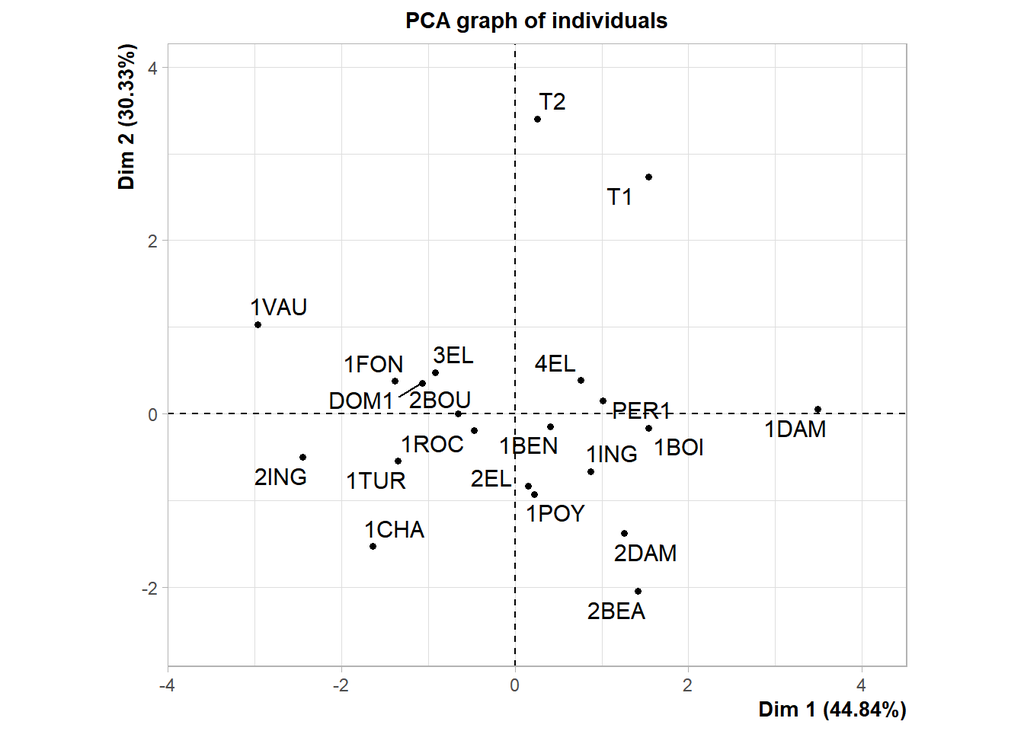

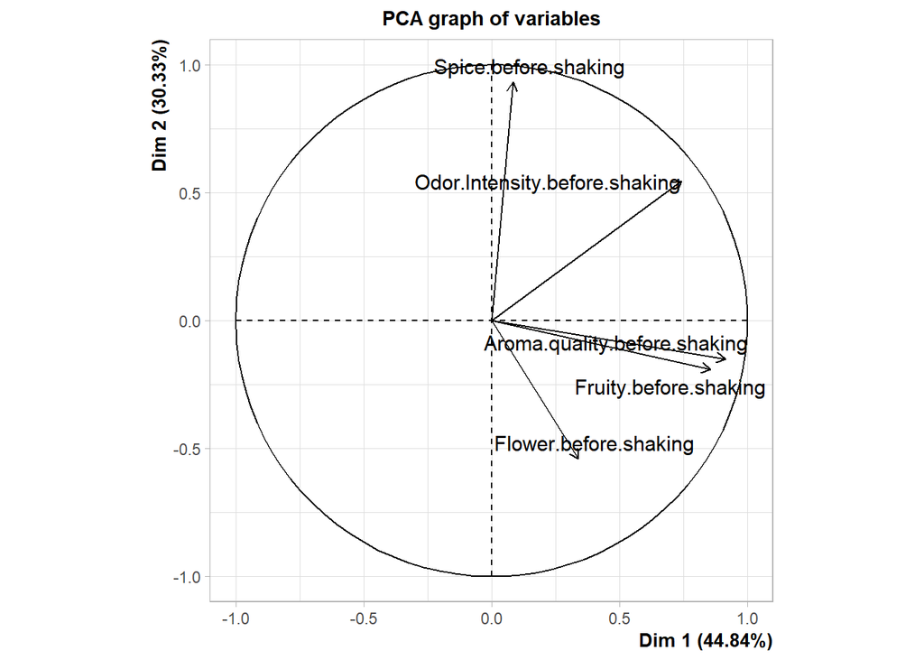

```r
res.pca2 <- PCA(group2)
```

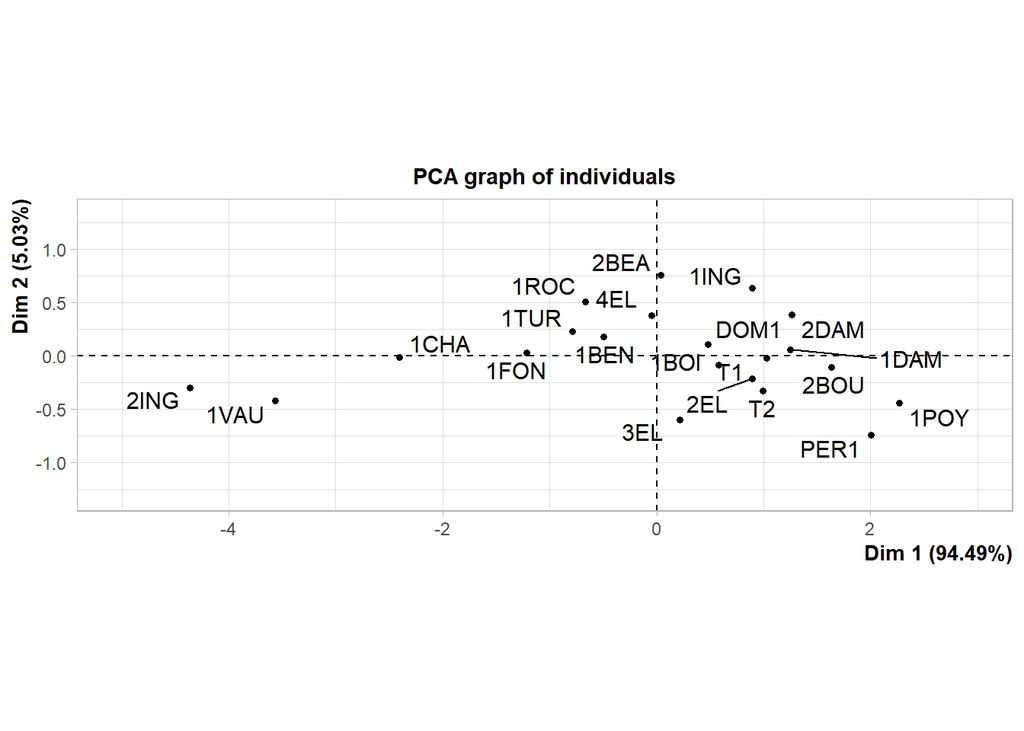

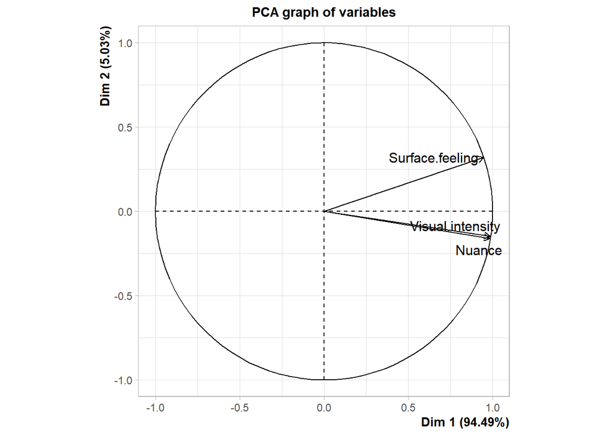

```r
res.pca3 <- PCA(group3)
```

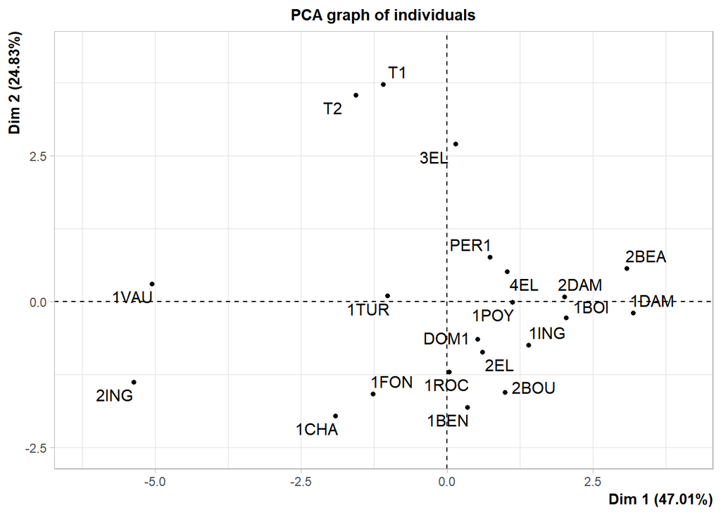

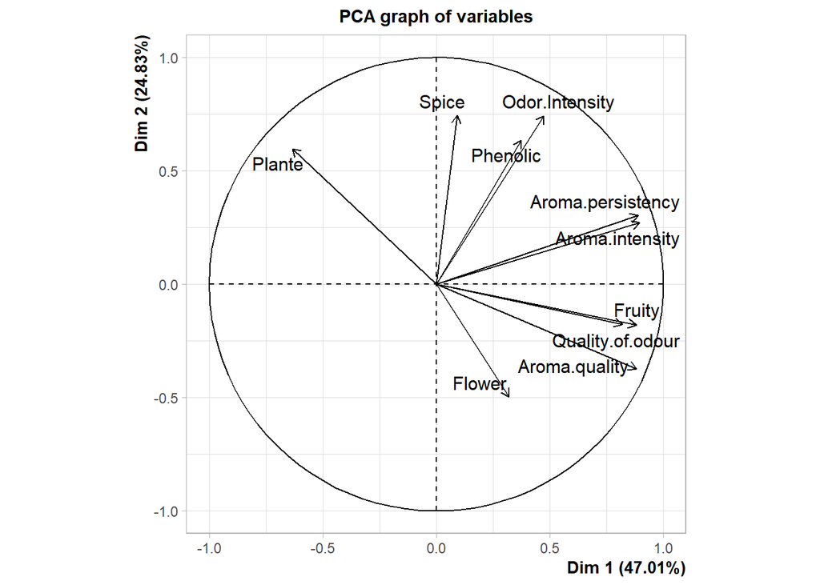

```r
res.pca4 <- PCA(group4)
```

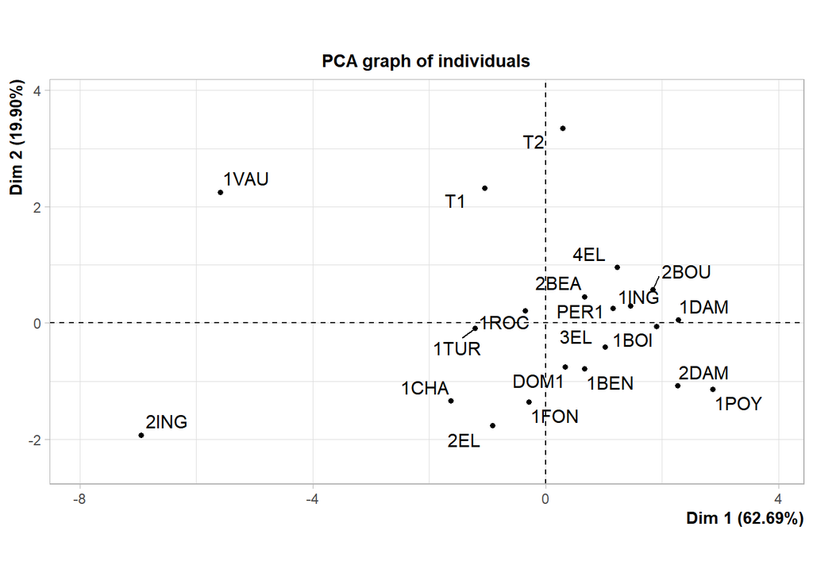

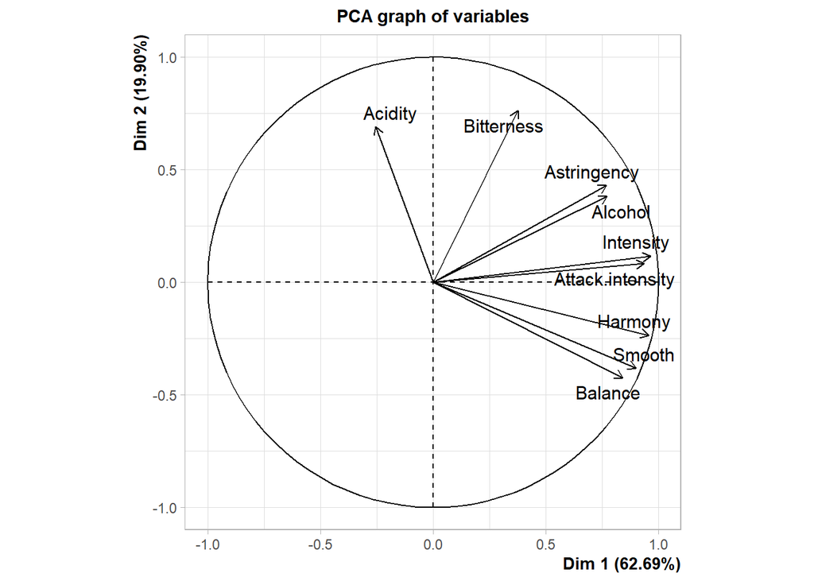

```r
# First eigen values of each PCA
egv1 <- res.pca1$eig[1]
egv2 <- res.pca2$eig[1]
egv3 <- res.pca3$eig[1]
egv4 <- res.pca4$eig[1]

# Vector of weight
w <- c(1/c(rep(egv1,5),rep(egv2,3),rep(egv3,10),rep(egv4,9) ))
res.pca.pon <- PCA(wine_quanti, col.w = w)
```

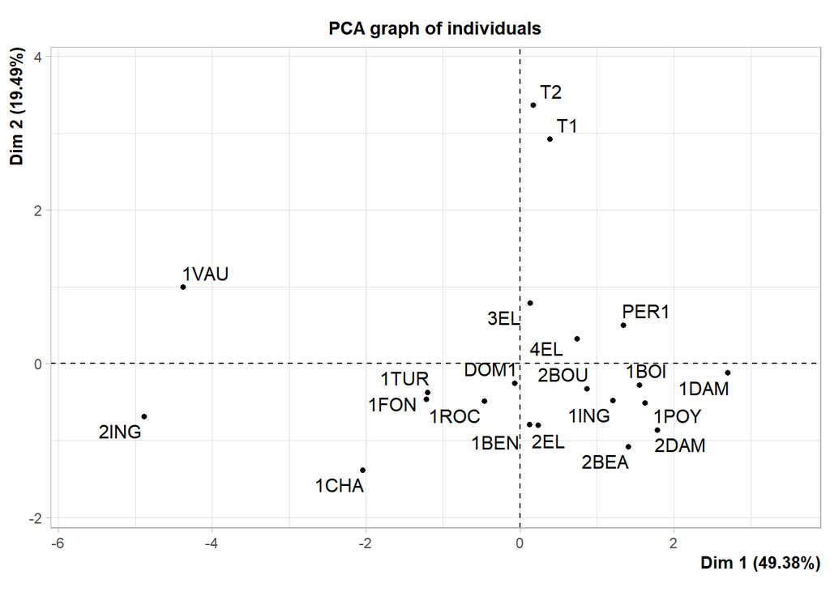

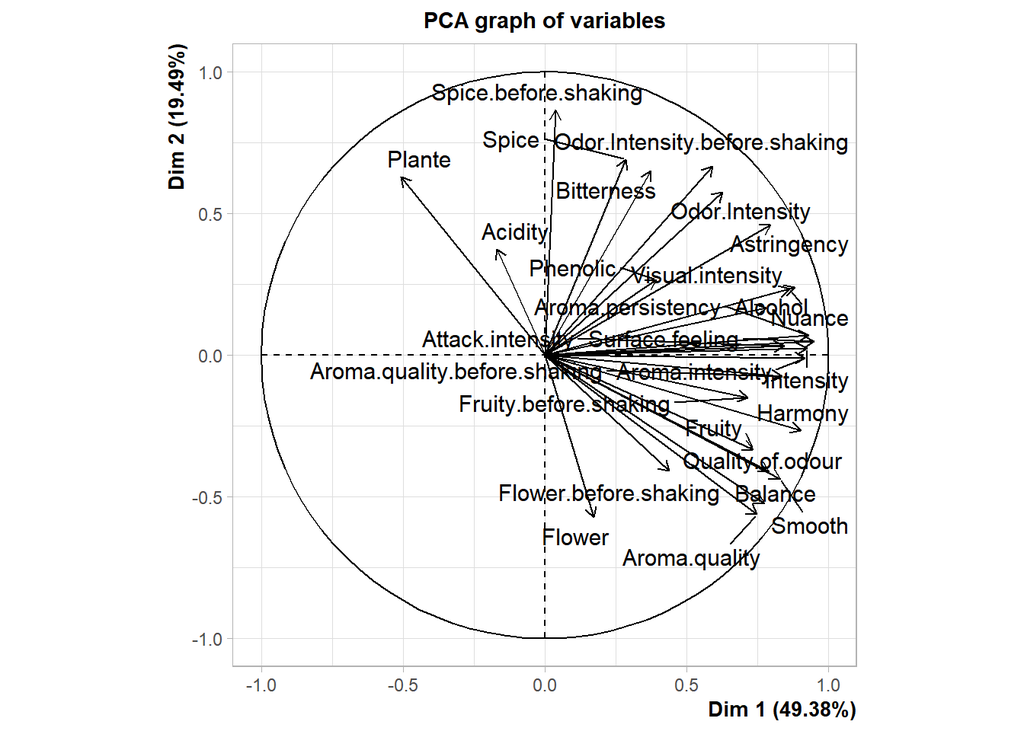

```r
coord_pca_pond <- res.pca.pon$ind$coord

res.pca.pon$eig
```

```
##          eigenvalue percentage of variance cumulative percentage of variance
## comp 1  3.461950436            49.37838239                          49.37838
## comp 2  1.366768270            19.49444613                          68.87283
## comp 3  0.615429078             8.77796864                          77.65080
## comp 4  0.372199671             5.30874662                          82.95954
## comp 5  0.270382485             3.85651094                          86.81605
## comp 6  0.202403306             2.88691245                          89.70297
## comp 7  0.175713405             2.50622990                          92.20920
## comp 8  0.125898681             1.79571410                          94.00491
## comp 9  0.105275528             1.50156260                          95.50647
## comp 10 0.078791202             1.12381220                          96.63029
## comp 11 0.073892411             1.05393990                          97.68423
## comp 12 0.060338440             0.86061733                          98.54484
## comp 13 0.028705009             0.40942438                          98.95427
## comp 14 0.021962548             0.31325552                          99.26752
## comp 15 0.019163991             0.27333923                          99.54086
## comp 16 0.010940292             0.15604323                          99.69691
## comp 17 0.009156013             0.13059375                          99.82750
## comp 18 0.006370966             0.09087016                          99.91837
## comp 19 0.003303413             0.04711714                          99.96549
## comp 20 0.002419756             0.03451339                         100.00000
```

```r
svd.triplet(scale(wine_quanti))
```

```
## $vs
##  [1] 3.61295326 2.20226543 1.38076901 1.12625464 1.01561112 0.87967909
##  [7] 0.84236691 0.70664232 0.62013776 0.57152922 0.54104222 0.44944501
## [13] 0.32917308 0.30363628 0.28135146 0.21358851 0.19973900 0.16698881
## [19] 0.11302799 0.09926405
##
## $U
##               [,1]       [,2]       [,3]        [,4]       [,5]        [,6]
##  [1,]  0.036255139 -0.7647504  1.0566915  1.31680667 -1.0922361 -0.76069998
##  [2,] -0.999859978 -1.1849182  1.9766596  0.93964272  0.2632444 -1.45854496
##  [3,] -0.530459656 -0.6644336  0.3297412 -2.19304355  0.1709513 -0.96532506
##  [4,] -2.380742580  0.8537871 -0.2401820  0.35022433  2.2625076  1.36991052
##  [5,]  1.323022707 -0.1459355 -0.8401188  0.62982139  1.2144731 -1.49706822
##  [6,]  0.566883246 -0.3244310  0.4248359 -1.64735226  0.2383087  1.21862241
##  [7,]  0.843547631 -0.2433954 -0.6147270 -0.56641861  1.4648831 -0.05431734
```

[output cut: 194 more lines]

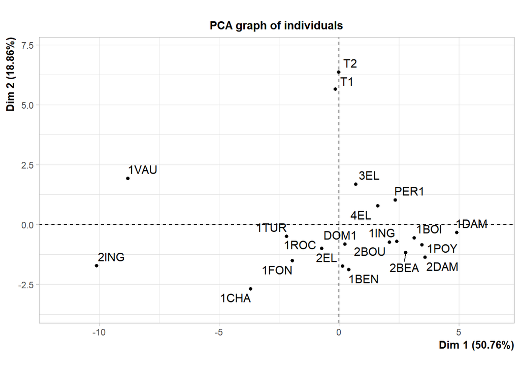

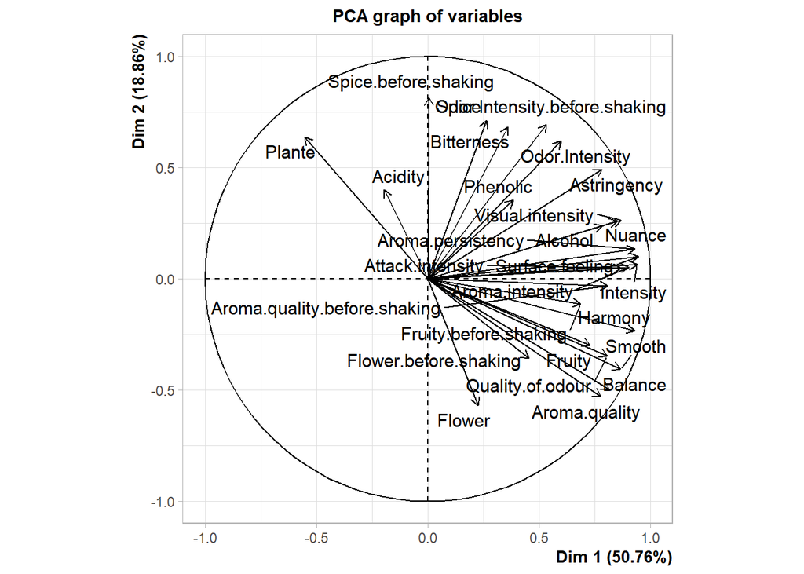

```
## $vs
##  [1] 3.7021754 2.2566505 1.4148672 1.1540676 1.0406917 0.9014028 0.8631692
##  [8] 0.7240929 0.6354521 0.5856432 0.5544033 0.4605441 0.3373020 0.3111346
## [15] 0.2882995 0.2188631 0.2046716 0.1711126 0.1158192 0.1017154
##
## $U
##               [,1]       [,2]       [,3]        [,4]       [,5]
##  [1,]  0.036255139 -0.7647504  1.0566915  1.31680667 -1.0922361
##  [2,] -0.999859978 -1.1849182  1.9766596  0.93964272  0.2632444
##  [3,] -0.530459656 -0.6644336  0.3297412 -2.19304355  0.1709513
##  [4,] -2.380742580  0.8537871 -0.2401820  0.35022433  2.2625076
##  [5,]  1.323022707 -0.1459355 -0.8401188  0.62982139  1.2144731
##  [6,]  0.566883246 -0.3244310  0.4248359 -1.64735226  0.2383087
##  [7,]  0.843547631 -0.2433954 -0.6147270 -0.56641861  1.4648831
##  [8,]  0.184774999  0.7499969  2.4551505  0.79606560 -0.5128170
```

[output cut: 43 more lines]

```r
PCA(wine_quanti)$svd
```

> Ajout des blocs déjà faits

# I. Variance and inertia

## Center of gravity

We have seen how to define the variance of a quantitative variable. We can also see the variance more geometrically on an axis. Let’s use the variable `Vanilla` from the same data set used in the lesson 1.

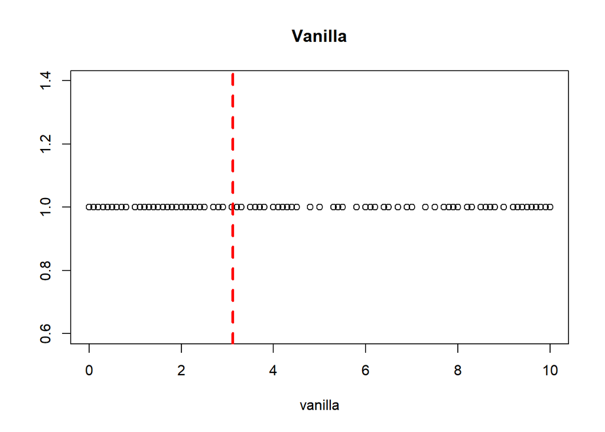

```r
vanilla <- experts$Vanilla

plot(x=vanilla, y=rep(1, length(vanilla)), main="Vanilla", ylab="")
abline(v = mean(vanilla), col="red", lwd=3, lty=2)
```

We can see the observations of the variable as points in a one-dimensional space with the mean center of gravity. Let us generalize this vision with two variables:

```r
df <- data.frame(experts$Vanilla, experts$Citrus)
colnames(df) <- c("Vanilla", "Citrus")
```

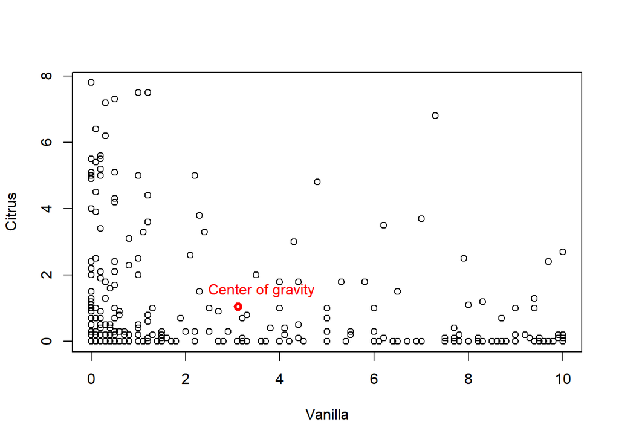

```r
plot(df)
points(x=mean(df$Vanilla),y=mean(df$Citrus), type="p", col="red",lwd=3, lty=2)
text(mean(df$Vanilla)+0.5, mean(df$Citrus)+0.5, "Center of gravity", col="red")
```

The center of gravity is the point
$$(\bar{Vanilla}, \bar{Citrus})$$
. If we take more than 2 variables, the center of gravity will be the matrix of means of variables. Let’s take all the quantitative variables of the data set :

```r
df <- data.frame(experts[,5:16])
```

Put the coordinates of the center of gravity for this dataframe :

```r
colMeans(df)
```

```
##     Spicy     Heady    Fruity     Green   Vanilla    Floral     Woody    Citrus
## 2.2493056 3.9628472 3.4868056 0.8458333 3.1131944 6.1187500 1.2524306 1.0489583
##    Marine    Greedy  Oriental  Wrapping
## 0.4673611 2.9236111 3.6993056 5.7368056
```

## Inertia

Now we have a point cloud with a center of gravity
$$G$$
. The distance that each individual has to this center of gravity can be calculated using the Euclidean distance:
$$d^2\left(x_{i},G\right) = \sum _{i=1}^{p} \left( x_{ij}-g_{j}\right)^2$$
with
$$p$$
the number of variables.

Let’s do it with all quantitative variables for the 10th first individuals. For this, you must to calculate the matrix of the center of gravity
$$n \times p$$
and the matrix of distances using the `apply()` function of R:

```r
matG <- matrix(colMeans(df[1:10,]), nrow(df[1:10,]), ncol(df) , byrow=TRUE)
apply((df[1:10,] - matG)^2, 1, sum)
```

```
##        1        2        3        4        5        6        7        8
##  54.8174  70.1114 108.5314  43.2574  84.1894 124.8754  61.6274  82.2814
##        9       10
## 100.5914  62.8834
```

Hide : the result is the vector of 10 distances of individuals between each coordinates of the enter of gravity.

```r
distG <- apply((df[1:10,] - matG)^2, 1, sum)
sum(distG)/(nrow(df[1:10,])-1)
```

```
## [1] 88.12956
```

## Sum of the variance

Build the vector of the variances of the 12 variables of df:

```r
variances <- c()
for (j in 1:12){
  variances <- cbind(variances, var(df[1:10,j]))
}
variances
```

```
##          [,1]     [,2]     [,3]      [,4]     [,5]     [,6]     [,7]     [,8]
## [1,] 6.884889 19.13656 13.11611 0.6721111 3.039556 4.649889 1.595111 5.362667
##          [,9]    [,10]    [,11]    [,12]
## [1,] 4.068889 13.74889 11.98322 3.871667
```

Now, calculate the sum of this vector :

```r
sum(variances)
```

```
## [1] 88.12956
```

Compare the result found here and the one found in the previous section. Then understand this:

$$\frac{1}{n}\sum_{i=1}^{n} d^{2}(x_{i}, g))\Leftrightarrow \frac{1}{n}\sum_{i=1}^{n} \sum_{j=1}^{p}(x_{ij}-x_{.j})^{2}))
\Leftrightarrow \sum_{j=1}^{p} \frac{1}{n}\sum_{i=1}^{n}(x_{ij}-x_{.j})^{2}))\Leftrightarrow \sum_{j=1}^{p} Var(X_{j}))$$

# II .Bivariate analysis: two quantitative variables

For this part, we focus on the relation between the variable `Fruity` and `Floral`. Exist it a relation between this two attributes ?

```r
df <- data.frame(experts$Fruity, experts$Floral)
colnames(df) <- c("Fruity", "Floral")
```

To begin, plot the observations of the `Floral` attribute in function of the `Fruity` attribuet :

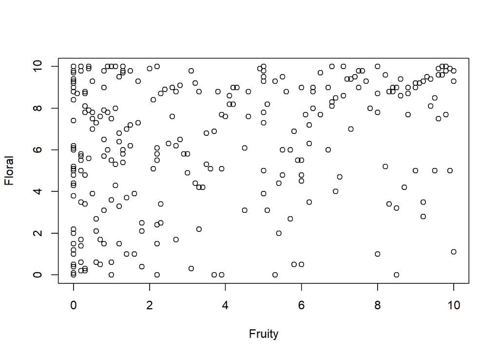

```r
plot(df)
```

## Covariance

In the first part of this lesson we calculate the variance for one variable. Here, we use the covariance matrix. It’s an indicator of the linear direction between 2 variables.

$$Cov(X,Y)=\frac{1}{N-1}\sum_{n}^{1}(x_{i}-\bar{x})(y_{i}-\bar{y})$$
Try to calculate manually the covariance between this two variable :

```r
N <- length(df$Floral)
1/(N-1)*sum((df$Fruity-mean(df$Fruity))*(df$Floral-mean(df$Floral)))
```

```
## [1] 3.377809
```

Verify your answer with the `cov()` function of R :

```r
cov(df$Fruity,df$Floral)
```

```
## [1] 3.377809
```

## Correlation

The correlation between two variables indicate any type of association refers to the degree to which a pair of variables are linearly related. It’s a measure of dependence, the most familiar measure is the Pearson correlation coefficient :
$$\rho_{XY} = corr(X,Y) = \frac{cov(X,Y)}{\sigma_{X}\sigma_{Y}}$$

Try to calculate the correlation coefficient between `Fruity` and `Floral` :

```r
cov <- 1/(N-1)*sum((df$Fruity-mean(df$Fruity))*(df$Floral-mean(df$Floral)))
cov / (sqrt(var(df$Fruity))*sqrt(var(df$Floral)))
```

```
## [1] 0.3188781
```

Verify your answer with the `cor()` function of R :

```r
cor(df$Fruity, df$Floral)
```

```
## [1] 0.3188781
```

# III. Test-F

## Context and formalisation

The test-F is a statistic test that determines the equality of variances of two populations, this makes it possible to compare two population variances. Both populations are presumed to be Gaussian.

Let
$$Y = (Y1, . . ,Y_{n_{1}})$$
a
$$n_{1}$$
-sample of law
$$\mathcal{N}(\mu_{1}, σ^{2}_{1})$$
and
$$Z = (Z_{1},...,Z_{n_{2}})$$
a
$$n_{2}$$
-sample of law
$$\mathcal{N}(\mu_{2}, σ^{2}_{2})$$
. Assume $Y$ and $Z$ are independent and pose
$$X = (Y,Z)$$
. So, here we test :

- $$H_{0} : σ^{2}_{1}=σ^{2}_{2}$$
  ;
- $$H_{1} : σ^{2}_{1} \ne σ^{2}_{2}$$
  .

## Construction of the test statistics

Variables
$$\frac{n_{1}S^{2}_{1}}{\sigma^{2}_{1}}$$
and
$$\frac{n_{2}S^{2}_{2}}{\sigma^{2}_{2}}$$
are independent and distributed according to the laws of the
$$\chi ^{2}(n_{1})$$
and
$$\chi ^{2}(n_{2})$$
with
$$S^{2}_{1}=\frac{1}{n_{1}-1}\sum_{1}^{n}(y_{i}-\bar{y})^2$$
and
$$S^{2}_{2}=\frac{1}{n_{2}-1}\sum_{1}^{n}(z_{i}-\bar{z})^2$$
.

Under the hypothesis of equality of variances we deduce that the random variable :

$$\frac{\frac{n_{1}S^{2}_{1}}{n_{1}-1}}{\frac{n_{2}S^{2}_{2}}{n_{2}-1}} \sim \mathcal{F}(n_{1}-1, n_{2}-1)$$

## Decision

In this case, the comparison test being bilateral, H0 is rejected at the risk threshold
$$\alpha$$
in the cases:

- $$f_{obs}\le f_{\frac{\alpha}{2}}(v_{1},v_{2})$$
  ;
- $$f_{obs}\ge f_{1-\frac{\alpha}{2}}(v_{1},v_{2})$$
  .

Hence the decision rule, H0 is rejected if :
$$f_{obs} \notin [f_{\frac{\alpha}{2}}(n_{1}-1,n_{2}-1),f_{1-\frac{\alpha}{2}}(n_{1}-1,n_{2}-1)]$$

## Practice

### Manually

In Argentina, an experiment was conducted in 2009 to solve problems related to the intensification of agriculture and especially to a new method cattle feeding. The traditional A.Angus breed is not adapted to this system breeding, a cross: A.Angus x Charolaise was created. The objective is to obtain animals better adapted to these new practices while maintaining a homogeneity comparable to the traditional breed. The character studied is the GMQ (Average Daily Gain) expressed in kg.

The results observed on two batches (here in the sense of “samples”) are as follows:

- for lot 1: pure breed, sample size 16, variance 0.26.
- for lot 2: cross-breed, sample size: 21, variance: 0.37.

Can we consider that the GMQ of cross A . Angus x Charolaise gives results as homogeneous as that of the pure race? (we will take a risk threshold of 0.05).

Calculate
$$f_{obs}$$
and the quantiles of the fisher law :

```r
f <- (16*0.26/15)/(21*0.37/20)
v1 <- qf(0.025,df1=15,df2=20)
v2 <- qf(0.975,df1=15,df2=20)
```

What’s the conclusion ? -
$$H0$$
rejected -
$$H0$$
not rejected

### Using R

```r
var.test(experts$Spicy, experts$Heady)
```

```
##
##  F test to compare two variances
##
## data:  experts$Spicy and experts$Heady
## F = 0.65448, num df = 287, denom df = 287, p-value = 0.0003511
## alternative hypothesis: true ratio of variances is not equal to 1
## 95 percent confidence interval:
##  0.5190462 0.8252493
## sample estimates:
## ratio of variances
##          0.6544789
```

Calculate manually the f-statistic :

```r
(288*var(experts$Spicy)/287)/(288*var(experts$Heady)/287)
```

```
## [1] 0.6544789
```

# IV. Test-T

## Utilisation

A Student’s t test, also known as a Student’s t test, is a tool for evaluating the means of one or two populations using a hypothesis test. A Student’s t-test can be used to evaluate whether a single group differs from a known value (one-sample t-test), whether two groups differ from each other (independent two-sample t-test), or whether there is a significant difference in paired measures (paired or dependent sample Student’s t-test).

## Understand the statistic

Let’s find manually the results of the statistic :

```r
x<-c(442.7, 380.2, 406.8, 507.7, 615.1, 486.8, 438.7, 390.7, 399.5, 789.9)
res<-t.test(x, mu=200) #real test


## find manually :
xbar <- (1/10)*sum(x) # estimate mean of x
diff <- x-xbar
sumsq <- (1/9)*sum(diff^2) # non-biaised estimate var of x
t <- sqrt(10)*(xbar-200)/sqrt(sumsq)
```

## Understand the test

### Contexte and formalisation

Let
$$X = (X_{1},...,X_{n_{1}})$$
a
$$n_{1}$$
-sample of law
$$\mathcal{N}(\mu_{1}, σ^{2}_{1})$$
and
$$Y = (Y1, . . ,Y_{n_{2}})$$
a
$$n_{2}$$
-sample of law
$$\mathcal{N}(\mu_{2}, σ^{2}_{2})$$
.
$$\bar{X}$$
(resp.
$$\bar{Y}$$
) always refers to the estimator of the expectation of the variable
$$X$$
(resp.
$$Y$$
) and
$$S^{2}_{1}$$
(resp.
$$S^{2}_{2}$$
) that of variance. So, here we test :

- $$H_{0} : \mu_{1}=\mu_{2}$$
  ;
- $$H_{1} : \mu_{1} \ne \mu_{2}$$
  . Testing
  $$\mu_{1}=\mu_{2}$$
  is therefore testing the mean
  $$\mu_{1}-\mu_{2}=0$$
  of a variable Gaussian random (
  $$\bar{X}$$
  -
  $$\bar{Y}$$
  ) and variance
  $$(\frac{S^{2}_{1}}{n_{1}}+\frac{S^{2}_{2}}{n_{2}})$$
  (
  $$σ^{2}_{1}$$
  and
  $$σ^{2}_{2}$$
  are unknown).

The test statistic is
$$T(X)=\frac{\bar{X}-\bar{Y}}{\sqrt{\frac{S^{2}_{1}}{n_{1}}+\frac{S^{2}_{2}}{n_{2}}}} \sim \mathcal{T}(n_{1}+n_{2}-2)$$
.

### Decision

In this case, the comparison test being bilateral, H0 is rejected at the risk threshold
$$\alpha$$
in the cases:

- $$t_{obs}\le t_{\frac{\alpha}{2}}(v_{1})$$
  ;
- $$t_{obs}\ge t_{1-\frac{\alpha}{2}}(v_{1})$$
  .

Hence the decision rule, H0 is rejected if :
$$t_{obs} \notin [t_{\frac{\alpha}{2}}(n_{1}+n_{2}-2),t_{1-\frac{\alpha}{2}}(n_{1}+n_{2}-2)]$$

### Practice

Using `Spicy` and `Heady` variables, calculate the t-statistic manually and verify your answer with the `t.test()` function :

```r
(mean(experts$Spicy) - mean(experts$Heady))/sqrt((var(experts$Spicy)/288)+(var(experts$Heady)/288))
```

```
## [1] -5.806802
```

```r
t.test(experts$Spicy, experts$Heady)
```

```
##
##  Welch Two Sample t-test
##
## data:  experts$Spicy and experts$Heady
## t = -5.8068, df = 550.01, p-value = 1.077e-08
## alternative hypothesis: true difference in means is not equal to 0
## 95 percent confidence interval:
##  -2.293187 -1.133896
## sample estimates:
## mean of x mean of y
##  2.249306  3.962847
```

What’s the conclusion ? -
$$H0$$
rejected -
$$H0$$
not rejected

# V. ANOVA

ANOVA tests whether any of the group means are different from the overall mean of the data by checking the variance of each individual group against the overall variance of the data, several T-test are performed for each modality. If one or more groups falls outside the range of variation predicted by the null hypothesis (all group means are equal), the test is statistically significant.

## One-way ANOVA

Let’s considere the categorical (qualitative) variable `Product` of the dataset and the quantitative variable `Woody` :

```r
df <- data.frame(experts$Product, experts$Woody)
colnames(df) <- c("Product", "Woody")
```

Build the model with the `aov()` function :

```r
one.way <- aov(Woody~Product, data=df)
```

Get the summary of the model :

```r
summary(one.way)
```

```
##              Df Sum Sq Mean Sq F value   Pr(>F)
## Product      11  143.8  13.073   4.712 1.29e-06 ***
## Residuals   276  765.8   2.775
## ---
## Signif. codes:  0 '***' 0.001 '**' 0.01 '*' 0.05 '.' 0.1 ' ' 1
```

```r
x1 <- 6.4*10.6
x2 <- x1*4
x3 <- 377.36 - x2
x4 <- x3/10.6
x5 <- 4+x4
```

The last column of the result of summary corresponds to the p-value of the F-statistic. This shows how likely is that the F-value alculated from the test would have occurred if the null hypothesis of no difference among group means were true.

Here the p-value of the `Wood` variable is low so it appears that the sensory attribut has a real impact on the different products, such as `Wood` are really specific to some products.

## Two-way ANOVA

```r
df <- cbind(df, experts$Session)
colnames(df) <- c("Product","Woody","Session")
```

Try to build the model :

```r
two.way <- aov(Woody~Product+Session, data=df)
summary(two.way)
```

```
##              Df Sum Sq Mean Sq F value   Pr(>F)
## Product      11  143.8  13.073   4.712 1.29e-06 ***
## Session       1    2.9   2.860   1.031    0.311
## Residuals   275  762.9   2.774
## ---
## Signif. codes:  0 '***' 0.001 '**' 0.01 '*' 0.05 '.' 0.1 ' ' 1
```

What can you conclude with this result ? - there is a highly significant Product effect: the products have been differentiated regarding the sensory attribute `Woody`; - there is a highly significant Product and Session effect: the products and the sessions have been differentiated regarding the sensory attribute `Woody`; - there is a highly significant Session effect: the sessions have been differentiated regarding the sensory attribute `Woody`.

## Adding interaction

Sometimes we can try an interaction effect rather than an additive effect of your independent variables. For example, we can try the hypothesis that the panel is not repeatable from one session to other which isn’t what we should expect from a sensory panel.

```r
interaction <- aov(Woody~Product*Session, data=df)
summary(interaction)
```

```
##                  Df Sum Sq Mean Sq F value   Pr(>F)
## Product          11  143.8  13.073   4.633 1.84e-06 ***
## Session           1    2.9   2.860   1.014    0.315
## Product:Session  11   18.1   1.641   0.582    0.843
## Residuals       264  744.9   2.822
## ---
## Signif. codes:  0 '***' 0.001 '**' 0.01 '*' 0.05 '.' 0.1 ' ' 1
```

For a better understanding of the notion of interaction, let’s use the graphinter function of the SensoMineR package. For a given couple of factors
$$A = (\alpha_{i})\quad i∈I$$
,
$$I$$
the panel space and
$$B = (\beta_{j} ) \quad j∈J$$
,
$$J$$
the product space, this function plots the means for each level
$$\alpha\beta_{ij}$$
of the interaction effect AB in an intuitive graphical output.

This function takes as argument the dataset, the position of the first then the second variables of the interaction and the first and last position of numerical variables.

```r
library(SensoMineR)
```

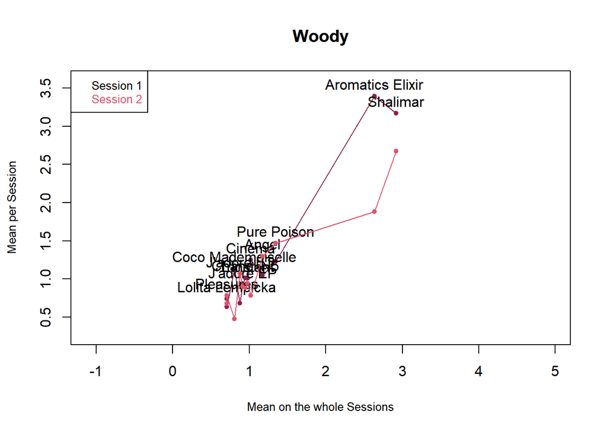

```
## $col.p
##                       Woody
## Angel             1.1750000
## Aromatics Elixir  2.6375000
## Chanel N5         0.9500000
## Cinéma            1.0166667
## Coco Mademoiselle 0.8041667
## J'adore EP        0.9125000
## J'adore ET        0.8750000
## L'instant         0.9750000
## Lolita Lempicka   0.7083333
## Pleasures         0.7083333
## Pure Poison       1.3458333
## Shalimar          2.9208333
##
## $col.j
## , , 1
##
##                       Woody
## Angel             1.0500000
## Aromatics Elixir  3.3916667
## Chanel N5         1.0166667
## Cinéma            1.2500000
## Coco Mademoiselle 1.1333333
## J'adore EP        0.9250000
## J'adore ET        0.6833333
## L'instant         1.0083333
## Lolita Lempicka   0.7416667
## Pleasures         0.6333333
## Pure Poison       1.2250000
## Shalimar          3.1666667
##
## , , 2
##
##                       Woody
## Angel             1.3000000
## Aromatics Elixir  1.8833333
## Chanel N5         0.8833333
## Cinéma            0.7833333
## Coco Mademoiselle 0.4750000
## J'adore EP        0.9000000
## J'adore ET        1.0666667
## L'instant         0.9416667
## Lolita Lempicka   0.6750000
## Pleasures         0.7833333
## Pure Poison       1.4666667
## Shalimar          2.6750000
```

```r
graphinter(df,col.p=1,col.j=3,firstvar=2,lastvar=2,numr=1,numc=1)
```

## decat function from *SensoMineR*

To get the list of attributes that structures the product space, the decat function of the SensoMineR package is used. This function systematically performs ANOVA on each sensory attribute using this model :

$$Attribut_{iks}\sim\mu + \alpha_{i} + \beta_{k} + \gamma_{s} + \alpha\beta_{ik} + \alpha\gamma_{is} + \beta\gamma_{ks} + \epsilon_{iks}$$

where

- $$\mu$$
  is the average effect so the average score;
- $$\alpha_{i}$$
  is
  $$i^{th}$$
  the coefficient associated with the *Product* effect;
- $$\beta_{k}$$
  is
  $$k^{th}$$
  the coefficient associated with the *Panelist* effect;
- $$\gamma_{s}$$
  is
  $$s^{th}$$
  the coefficient associated with the *Session* effect;
- $$\alpha\beta_{ik}$$
  is
  $$ik^{th}$$
  the coefficient associated with the *Product-Panelist* interaction;
- $$\alpha\gamma_{is}$$
  is
  $$is^{th}$$
  the coefficient associated with the *Product-Session* interaction;
- $$\beta\gamma_{ks}$$
  is
  $$ks^{th}$$
  the coefficient associated with the *Panelist-Session* interaction;
- and
  $$\epsilon_{iks}$$
  denotes the error term.

```r
res.decat <- decat(experts,formul="~Product+Panelist+Session",firstvar=5, lastvar=ncol(experts),graph=FALSE)
names(res.decat)
```

```
## [1] "tabF"    "tabT"    "coeff"   "adjmean" "resF"    "resT"
```

This output highlights the sensory attributes for which products are differentiated at a significance threshold of 0.05 :

```r
res.decat$resF
```

```
##              Vtest      P-value
## Heady    15.814715 1.231605e-56
## Greedy   15.490029 2.025533e-54
## Vanilla  13.153201 8.156043e-40
## Spicy    12.460920 6.097793e-36
## Floral   11.549970 3.692291e-31
## Oriental  9.860837 3.076723e-23
## Fruity    9.596498 4.135338e-22
## Wrapping  8.942211 1.907302e-19
## Green     7.771046 3.892033e-15
## Woody     5.513095 1.762893e-08
## Citrus    2.511698 6.007586e-03
## Marine    1.664085 4.804767e-02
```

Try to find the same p-value for `Heady` with the `aov()` function :

```r
heady.aov <- aov(Heady~Product+Panelist+Session+Product:Panelist+Product:Session+Panelist:Session, data=experts)
summary(heady.aov)
```

```
##                   Df Sum Sq Mean Sq F value   Pr(>F)
## Product           11 2639.4  239.95  84.502  < 2e-16 ***
## Panelist          11  390.5   35.50  12.504 1.70e-15 ***
## Session            1    1.0    1.04   0.366    0.546
## Product:Panelist 121  890.2    7.36   2.591 1.44e-07 ***
## Product:Session   11   34.9    3.18   1.118    0.353
## Panelist:Session  11   50.7    4.61   1.624    0.100
## Residuals        121  343.6    2.84
## ---
## Signif. codes:  0 '***' 0.001 '**' 0.01 '*' 0.05 '.' 0.1 ' ' 1
```

# VI. Khi²

## Cross tabulation

The easiest way to obtain a cross tabulation is to use the table function by giving it as parameters the two variables to cross.

```r
library(dplyr)
library(questionr)
data_fruity <- experts %>% filter(Fruity>6)
data_table <- table(data_fruity$Product)
tab <- table(data_fruity$Product, data_fruity$Panelist)
cprop(tab)
```

```
##
##                     CM    CR    GV    MLD   NMA   PR    RL    SD    SM    SO
##   Angel               0.0  16.7   0.0   0.0   0.0   0.0   0.0   0.0   0.0   0.0
##   Cinéma             20.0   0.0  14.3  20.0   0.0   0.0  33.3   0.0   0.0  10.0
##   Coco Mademoiselle   0.0   0.0  28.6  20.0  16.7   0.0   0.0   0.0   0.0  20.0
##   J'adore EP         20.0  16.7  14.3  20.0  16.7  50.0   0.0  50.0  33.3  20.0
##   J'adore ET          0.0  16.7  14.3  20.0   0.0  50.0   0.0  50.0  33.3  20.0
##   L'instant           0.0  16.7  14.3   0.0  33.3   0.0   0.0   0.0   0.0   0.0
##   Lolita Lempicka    40.0  16.7  14.3   0.0   0.0   0.0   0.0   0.0   0.0  10.0
##   Pleasures          20.0  16.7   0.0  20.0  16.7   0.0  33.3   0.0   0.0  10.0
##   Pure Poison         0.0   0.0   0.0   0.0  16.7   0.0  33.3   0.0  33.3  10.0
##   Total             100.0 100.0 100.0 100.0 100.0 100.0 100.0 100.0 100.0 100.0
##
##                     ST    Ensemble
##   Angel               0.0   2.7
##   Cinéma             15.4  11.0
##   Coco Mademoiselle  15.4  12.3
##   J'adore EP         15.4  19.2
##   J'adore ET         15.4  16.4
##   L'instant          15.4   9.6
##   Lolita Lempicka     0.0   8.2
##   Pleasures           7.7  12.3
##   Pure Poison        15.4   8.2
##   Total             100.0 100.0
```

## Study the cross table of the 2 variables

The idea is if two variables I and J are independent, then we expect the number of individuals nij who satisfy I and J to be equal to eff_theo = ni.*nj./n On the contrary, if nij is significantly different from fi*nj , the more reason here is to think that I and J are not independent.

Studying a correlation between two categorical variables leads to comparing the nij with the eff_theo.

```r
data(tea)
summary(tea)
```

```
##          breakfast           tea.time          evening          lunch
##  breakfast    :144   Not.tea time:131   evening    :103   lunch    : 44
##  Not.breakfast:156   tea time    :169   Not.evening:197   Not.lunch:256
##
##
##
##
##
##         dinner           always          home           work
##  dinner    : 21   always    :103   home    :291   Not.work:213
##  Not.dinner:279   Not.always:197   Not.home:  9   work    : 87
##
##
##
##
##
##         tearoom           friends          resto          pub
##  Not.tearoom:242   friends    :196   Not.resto:221   Not.pub:237
##  tearoom    : 58   Not.friends:104   resto    : 79   pub    : 63
##
##
##
##
##
##         Tea         How           sugar                     how
##  black    : 74   alone:195   No.sugar:155   tea bag           :170
##  Earl Grey:193   lemon: 33   sugar   :145   tea bag+unpackaged: 94
##  green    : 33   milk : 63                  unpackaged        : 36
##                  other:  9
##
##
##
##                   where                 price          age        sex
##  chain store         :192   p_branded      : 95   Min.   :15.00   F:178
##  chain store+tea shop: 78   p_cheap        :  7   1st Qu.:23.00   M:122
##  tea shop            : 30   p_private label: 21   Median :32.00
##                             p_unknown      : 12   Mean   :37.05
##                             p_upscale      : 53   3rd Qu.:48.00
##                             p_variable     :112   Max.   :90.00
##
```

[output cut: 25 more lines]

```
##  feminine    :129   Not.sophisticated: 85   No.slimming:255   exciting   :116
##  Not.feminine:171   sophisticated    :215   slimming   : 45   No.exciting:184
##
##
##
##
##
##         relaxing              effect.on.health
##  No.relaxing:113   effect on health   : 66
##  relaxing   :187   No.effect on health:234
##
##
##
##
##
```

```r
tab <- table(tea$breakfast,tea$tea.time)
tab
```

```
##
##                 Not.tea time tea time
##   breakfast               55       89
##   Not.breakfast           76       80
```

construct the theorical table :

```r
theo11 <- (sum(tab[1,])*sum(tab[,1]))/sum(tab)
theo12 <- (sum(tab[1,])*sum(tab[,2]))/sum(tab)
theo21 <- (sum(tab[2,])*sum(tab[,1]))/sum(tab)
theo22 <- (sum(tab[2,])*sum(tab[,2]))/sum(tab)
theo <- cbind(c(theo11,theo21),c(theo12,theo22))
colnames(theo)<-colnames(tab)
row.names(theo)<- row.names(tab)
theo
```

```
##               Not.tea time tea time
## breakfast            62.88    81.12
## Not.breakfast        68.12    87.88
```

```r
tab
```

```
##
##                 Not.tea time tea time
##   breakfast               55       89
##   Not.breakfast           76       80
```

We have to compare now the 2 tables.

First, we substract all theorical values to experimental values:

```r
newtab <- tab-theo
```

Then we take the square value:

```r
newtab <- newtab^2
```

Finally, we divide by the theorical effectifs :

```r
newtab <- newtab/theo
newtab
```

```
##
##                 Not.tea time  tea time
##   breakfast        0.9875064 0.7654635
##   Not.breakfast    0.9115443 0.7065817
```

This table is called the table of deviations from independence

The sum of the table give the Chi2 statistic:

```r
chi2 <- sum(newtab)
chi2
```

```
## [1] 3.371096
```

# VII. condes()

## What’s the concept?

The `condes()` function from FactoMineR is using when you want to comparate a quantitative variable with other variable. The function identifies the type of others by itself and returns

- the description of the `num.var` by the quantitative variables in the `quanti` argument or/and the categorical variables which characterized the continuous variable renseigned in `num.var`, in the `quali` argument;
- and when others variables are qualitatives, the `category` returns a description of the continuous variable `num.var` by each category of all the categorical variables.

## Compare with a quantitative variable

In our case, we use the function on the data frame composed of `Floral` and `Fruity` variables :

```r
res.condes <- condes(donnee = data.frame(experts$Fruity, experts$Floral), num.var = 1)
```

Reminder the description of the function, in our case, what’s return ? - only `quanti` - `quanti` and `quali` - `quanti`, `quali` and `category`

Let’s get a look on argument(s) :

```r
res.condes$quanti
```

```
##                correlation      p.value
## experts.Floral   0.3188781 3.145829e-08
```

Here, it’s tested if the correlation coefficient is significantly different from zero. The null hypothesis is
$$H0 : \rho = 0$$
, there is not significant linear relationship between the two variables and the alternate hypothesis is
$$H1 : \rho \ne 0$$
. Get a look on the p-value, what can you conclude ? - there is a significant linear relationship between `Fruity` and `Floral`; - there is not a significant linear relationship between `Fruity` and `Floral`. *Hind* : When the p-value < 0.05, H0 is rejected. It’s the case here so there is a significant correlation between them.

## Compare with a qualitative variable

```r
res.condes <- condes(donnee = data.frame(experts$Fruity, experts$Product), num.var = 1)
res.condes$quali
```

```
##                        R2      p.value
## experts.Product 0.3364909 1.834564e-19
```

Here a one-factor variance analysis test is performed.

The first argument is the
$$R^{2}$$
statistic. It represents the percentage of variation in a response variable (here `Fruity`) explained by its relationship with one or more predictor (here `Product`).

The second argument is the p-value from an ANOVA.

With this result, what can you conclude ? - the products have been differentiated regarding the sensory attribute `Fruity`; - the products haven’t been differentiated regarding the sensory attribute `Fruity`

## Use all the data

Let’s apply on the entire dataset. We choose to describe the first quantitative variable `Spicy` :

```r
res.condes <- condes(donnee = experts, num.var = 5)
```

Print results for the quantitative variables first, then for the qualitative variables:

```r
res.condes$quanti
```

```
##          correlation      p.value
## Heady      0.6600235 2.115480e-37
## Oriental   0.5746949 1.033259e-26
## Wrapping   0.4054195 8.062952e-13
## Woody      0.3900676 6.662342e-12
## Vanilla    0.1559591 8.014781e-03
## Citrus    -0.1345029 2.242761e-02
## Green     -0.1411124 1.655947e-02
## Fruity    -0.3514545 8.501233e-10
## Floral    -0.3540310 6.273945e-10
```

```r
res.condes$quali
```

```
##                 R2      p.value
## Product  0.4539609 1.444200e-30
## Panelist 0.1231426 1.219991e-04
```

You can see that only significant variables are displayed in both cases.

Next, an other result of the `condes` function is :

```r
res.condes$category
```

```
##                            Estimate      p.value
## Product=Aromatics Elixir   4.054861 7.857853e-12
## Product=Shalimar           3.913194 4.623115e-11
## Panelist=NMA               2.775694 4.642950e-06
## Product=Angel              1.650694 7.111351e-03
## Product=Chanel N5          1.484028 1.565503e-02
## Rank=1                    -1.228472 4.577800e-02
## Product=Coco Mademoiselle -1.336806 2.963114e-02
## Panelist=SM               -1.399306 2.275146e-02
## Product=L'instant         -1.511806 1.379422e-02
## Panelist=CR               -1.595139 9.325197e-03
## Product=Pleasures         -1.757639 4.125228e-03
## Product=J'adore ET        -1.907639 1.825387e-03
## Product=J'adore EP        -1.986806 1.158113e-03
```

In practice, this result is more important than the other two because we’re interested by the differences within the product groups themselves. The p-value returned is that of the t-test. Here, for each product
$$i$$
the t-test is performed with
$$H0: \mu_{i} = \mu$$
with
$$\mu_{i}$$
the mean estimator of `Spicy` in the group
$$i$$
and
$$\mu$$
the mean estimator for the global population.

# VIII. catdes()

## What’s the concept?

The `catdes()` function from FactoMineR is using when you want to comparate a qualitative variable with other variable. The function identifies the type of others by itself and returns

- the description of the `num.var` by the quantitative variables in the `quanti` argument and the
  $$\eta^{2}$$
  -score in for each quantitative variable in the `quanti.var` argument;
- the categorical variables which characterized the continuous variable renseigned in `num.var`, in the `test.chi2` argument; and the `category` returns a description of the continuous variable `num.var` by each category of all the categorical variables.

## Compare with a quantitative variable

Let’s start to compare the variable `Product` with the quantitative variable `Green`

```r
res.catdes <- catdes(donnee = data.frame(experts$Product, experts$Green), num.var = 1)
```

Reminder the description of the function, in our case, what’s return ? - only `quanti`; - `quanti` and `quanti.var`; - only `test.chi2`; - `test.chi2` and `category`; - `quanti`, `quanti.var`,`test.chi2` and `category`.

Let’s get a look on argument(s) :

```r
res.catdes$quanti.var
```

```
##                    Eta2      P-value
## experts.Green 0.2555684 4.331956e-13
```

```r
res.catdes$quanti
```

```
## $Angel
##                  v.test Mean in category Overall mean sd in category Overall sd
## experts.Green -2.235428           0.1125    0.8458333      0.1786815   1.675658
##                  p.value
## experts.Green 0.02538928
##
## $`Aromatics Elixir`
## NULL
##
## $`Chanel N5`
## NULL
##
## $Cinéma
## NULL
##
## $`Coco Mademoiselle`
## NULL
##
## $`J'adore EP`
##                 v.test Mean in category Overall mean sd in category Overall sd
## experts.Green 2.184623           1.5625    0.8458333       2.076418   1.675658
##                  p.value
## experts.Green 0.02891653
##
## $`J'adore ET`
## NULL
##
## $`L'instant`
## NULL
##
## $`Lolita Lempicka`
## NULL
##
## $Pleasures
##                 v.test Mean in category Overall mean sd in category Overall sd
## experts.Green 7.328647             3.25    0.8458333       2.983426   1.675658
##                    p.value
## experts.Green 2.324885e-13
##
## $`Pure Poison`
## NULL
##
## $Shalimar
## NULL
```

In `quanti.var`,
$$\eta^{2}$$
ranges from 0 to 1 and where values closer to 1 indicate a higher proportion of variance can be explained by a given variable in the ANOVA model performed. The p-value is that of this one-factor ANOVA.

In `quanti`, the v-test performed is very close to the notion of z-score. In its basic form, the V-test is the quantile of a standardized normal distribution (with mean equal to 0 and standard deviation equal to 1) corresponding to a given probability. It is used to transform p-values into scores that are more easily interpretable. The result is displayed as “NULL” for certain modality. This is because the probability used is by default 5%. To display the results for all modalities, change the `proba` argument. Do it:

```r
catdes(donnee = data.frame(experts$Product, experts$Green), num.var = 1, proba=1)
```

```
##
## Link between the cluster variable and the quantitative variables
## ================================================================
##                    Eta2      P-value
## experts.Green 0.2555684 4.331956e-13
##
## Description of each cluster by quantitative variables
## =====================================================
## $Angel
##                  v.test Mean in category Overall mean sd in category Overall sd
## experts.Green -2.235428           0.1125    0.8458333      0.1786815   1.675658
##                  p.value
## experts.Green 0.02538928
##
## $`Aromatics Elixir`
##                  v.test Mean in category Overall mean sd in category Overall sd
## experts.Green -1.003402        0.5166667    0.8458333      0.9361564   1.675658
##                 p.value
## experts.Green 0.3156668
##
## $`Chanel N5`
##                  v.test Mean in category Overall mean sd in category Overall sd
## experts.Green -1.244727           0.4375    0.8458333      0.6136044   1.675658
##                 p.value
## experts.Green 0.2132322
##
## $Cinéma
##                  v.test Mean in category Overall mean sd in category Overall sd
## experts.Green -1.930597           0.2125    0.8458333      0.2962438   1.675658
##                  p.value
## experts.Green 0.05353295
##
## $`Coco Mademoiselle`
##                   v.test Mean in category Overall mean sd in category
## experts.Green -0.2032207        0.7791667    0.8458333       1.367473
##               Overall sd   p.value
## experts.Green   1.675658 0.8389625
##
## $`J'adore EP`
##                 v.test Mean in category Overall mean sd in category Overall sd
```

[output cut: 24 more lines]

```
## experts.Green 7.328647             3.25    0.8458333       2.983426   1.675658
##                    p.value
## experts.Green 2.324885e-13
##
## $`Pure Poison`
##                   v.test Mean in category Overall mean sd in category
## experts.Green -0.6604673        0.6291667    0.8458333       1.671197
##               Overall sd  p.value
## experts.Green   1.675658 0.508954
##
## $Shalimar
##                  v.test Mean in category Overall mean sd in category Overall sd
## experts.Green -1.422545        0.3791667    0.8458333      0.7566258   1.675658
##                 p.value
## experts.Green 0.1548681
```

## Compare with a qualitative variable

Let’s compare the same `Product` variable but with `Session`. Write the line and look to the result :

```r
res.catdes <- catdes(donnee = data.frame(experts$Product, experts$Session), num.var = 1)
```

Why is it NULL ? Try an other solution :

```r
res.catdes <- catdes(donnee = data.frame(experts$Product, experts$Session), num.var = 1, proba = 1)
```

Reminder the description of the function, in our case, what’s return ? - only `quanti`; - `quanti` and `quanti.var`; - only `test.chi2`; - `test.chi2` and `category`; - `quanti`, `quanti.var`,`test.chi2` and `category`.

Get this argument(s) :

```r
res.catdes$test.chi2
```

```
##                 p.value df
## experts.Session       1 11
```

```r
res.catdes$category
```

```
## $Angel
##                    Cla/Mod Mod/Cla Global p.value        v.test
## experts.Session=2 8.333333      50     50       1 -1.391458e-16
## experts.Session=1 8.333333      50     50       1 -1.391458e-16
##
## $`Aromatics Elixir`
##                    Cla/Mod Mod/Cla Global p.value        v.test
## experts.Session=2 8.333333      50     50       1 -1.391458e-16
## experts.Session=1 8.333333      50     50       1 -1.391458e-16
##
## $`Chanel N5`
##                    Cla/Mod Mod/Cla Global p.value        v.test
## experts.Session=2 8.333333      50     50       1 -1.391458e-16
## experts.Session=1 8.333333      50     50       1 -1.391458e-16
##
## $Cinéma
##                    Cla/Mod Mod/Cla Global p.value        v.test
## experts.Session=2 8.333333      50     50       1 -1.391458e-16
## experts.Session=1 8.333333      50     50       1 -1.391458e-16
##
## $`Coco Mademoiselle`
##                    Cla/Mod Mod/Cla Global p.value        v.test
## experts.Session=2 8.333333      50     50       1 -1.391458e-16
## experts.Session=1 8.333333      50     50       1 -1.391458e-16
##
## $`J'adore EP`
##                    Cla/Mod Mod/Cla Global p.value        v.test
## experts.Session=2 8.333333      50     50       1 -1.391458e-16
## experts.Session=1 8.333333      50     50       1 -1.391458e-16
##
## $`J'adore ET`
##                    Cla/Mod Mod/Cla Global p.value        v.test
## experts.Session=2 8.333333      50     50       1 -1.391458e-16
## experts.Session=1 8.333333      50     50       1 -1.391458e-16
##
## $`L'instant`
##                    Cla/Mod Mod/Cla Global p.value        v.test
## experts.Session=2 8.333333      50     50       1 -1.391458e-16
## experts.Session=1 8.333333      50     50       1 -1.391458e-16
##
## $`Lolita Lempicka`
##                    Cla/Mod Mod/Cla Global p.value        v.test
## experts.Session=2 8.333333      50     50       1 -1.391458e-16
## experts.Session=1 8.333333      50     50       1 -1.391458e-16
##
## $Pleasures
##                    Cla/Mod Mod/Cla Global p.value        v.test
## experts.Session=2 8.333333      50     50       1 -1.391458e-16
## experts.Session=1 8.333333      50     50       1 -1.391458e-16
##
## $`Pure Poison`
##                    Cla/Mod Mod/Cla Global p.value        v.test
## experts.Session=2 8.333333      50     50       1 -1.391458e-16
## experts.Session=1 8.333333      50     50       1 -1.391458e-16
##
## $Shalimar
##                    Cla/Mod Mod/Cla Global p.value        v.test
## experts.Session=2 8.333333      50     50       1 -1.391458e-16
## experts.Session=1 8.333333      50     50       1 -1.391458e-16
```

In the `test.chi2` argument, like its name, it’s the
$$\chi^{2}$$
-test result. The important part is in `category` :

- Cla/mod : proportion of individuals of this group in this modality : 8.33% of individuals in the first Session noted the product Angel;
- Mod/Cla : proportion of individuals of this modality in this group : 50% of individuals who voted Angel was in the first Session;
- p.value : significance level of the over-representation in the group of the modality;
- v.test : value of the test statistic used to determine the significance of the descriptive variables of the group. If it’s positive there is a over representation of the modality and vice versa.

## Use all the data

Let’s apply on the entire dataset. We choose to describe the variable `Product` :

```r
res.catdes <- catdes(donnee = experts, num.var = 4)
```

```r
res.catdes$test.chi2
```

```
##      p.value df
```

```r
res.catdes$quanti.var
```

```
##                Eta2      P-value
## Greedy   0.63222756 1.291696e-53
## Heady    0.60670435 1.129500e-49
## Vanilla  0.50618566 2.208514e-36
## Spicy    0.45396094 1.444200e-30
## Floral   0.39224356 1.980821e-24
## Fruity   0.33649093 1.834564e-19
## Oriental 0.33481328 2.542887e-19
## Wrapping 0.28130222 5.134241e-15
## Green    0.25556840 4.331956e-13
## Woody    0.15809402 1.285010e-06
## Citrus   0.07909313 1.706424e-02
```

```r
res.catdes$quanti
```

```
## $Angel
##             v.test Mean in category Overall mean sd in category Overall sd
## Greedy    7.277812         7.887500    2.9236111      2.8905467   3.483901
## Vanilla   5.968284         7.183333    3.1131944      2.7716822   3.483408
## Heady     5.097723         7.841667    3.9628472      2.7478653   3.886583
## Wrapping  2.716672         7.550000    5.7368056      2.8955426   3.409194
## Spicy     2.681609         3.900000    2.2493056      3.3704599   3.144241
## Green    -2.235428         0.112500    0.8458333      0.1786815   1.675658
## Fruity   -2.451807         1.920833    3.4868056      2.2827212   3.262439
## Floral   -5.725913         2.491667    6.1187500      2.4872871   3.235619
##               p.value
## Greedy   3.392779e-13
## Vanilla  2.397616e-09
## Heady    3.437642e-07
## Wrapping 6.594184e-03
## Spicy    7.326896e-03
## Green    2.538928e-02
## Fruity   1.421408e-02
## Floral   1.028790e-08
##
## $`Aromatics Elixir`
##             v.test Mean in category Overall mean sd in category Overall sd
## Spicy     6.587260        6.3041667     2.249306      2.9999277   3.144241
## Heady     5.711037        8.3083333     3.962847      2.2427507   3.886583
## Oriental  4.865247        7.4500000     3.699306      2.4467666   3.937780
## Woody     3.980958        2.6375000     1.252431      2.2143119   1.777168
## Wrapping  2.972629        7.7208333     5.736806      2.2737596   3.409194
## Floral   -2.877756        4.2958333     6.118750      3.1749645   3.235619
## Greedy   -3.785521        0.3416667     2.923611      0.6744854   3.483901
## Fruity   -4.500235        0.6125000     3.486806      1.2377104   3.262439
##               p.value
## Spicy    4.480174e-11
## Heady    1.122896e-08
## Oriental 1.143142e-06
## Woody    6.863812e-05
## Wrapping 2.952616e-03
## Floral   4.005144e-03
## Greedy   1.533868e-04
## Fruity   6.787843e-06
##
```

[output cut: 142 more lines]

```
## Oriental  5.086845         7.620833     3.699306       2.919472   3.937780
## Woody     4.795313         2.920833     1.252431       2.551957   1.777168
## Wrapping  2.392045         7.333333     5.736806       2.733841   3.409194
## Floral   -2.562025         4.495833     6.118750       3.191327   3.235619
## Greedy   -2.728670         1.062500     2.923611       1.874347   3.483901
## Fruity   -4.010961         0.925000     3.486806       1.074418   3.262439
##               p.value
## Spicy    2.055745e-10
## Heady    2.496565e-07
## Oriental 3.640701e-07
## Woody    1.624213e-06
## Wrapping 1.675478e-02
## Floral   1.040637e-02
## Greedy   6.359023e-03
## Fruity   6.047218e-05
```